# Mestrado em Hemoterapia: Bioestatística

## Estatísticas Sumárias: resumindo dados

## Introdução

Vimos anteriormente como usar gráficos e tabelas para resumir os dados.

Podemos também usar **estatísticas**: quantidades numéricas calculadas a partir dos dados.

Por exemplo, podemos estar interessados em encontrar qual seria um valor “típico” do conjunto de dados.

Podemos então usar uma estatística que descreva o centro da distribuição dos dados.

**Objetivo**: resumir os dados, através de valores que representem o conjunto de dados em relação à alguma característica (posição, dispersão).

## Medidas de Posição Central

## Média Aritmética

Se \(x_1, x_2, \ldots, x_n\) são as \(n\) observações, a média é:

\[\bar{x}=\frac{1}{n}\sum_{i=1}^nx_i\,.\]

A média pode ser interpretada como o ponto de equilíbrio de uma distribuição.

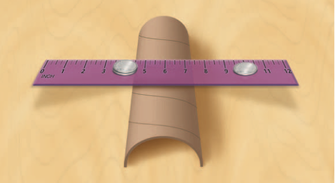

## Exemplo: Pressão sistólica

Pressão sistólica de 40 pacientes:

| 130 | 120 | 140 | 124 |
| --- | --- | --- | --- |
| 130 | 116 | 134 | 130 |
| 115 | 138 | 130 | 140 |
| 120 | 140 | 150 | 150 |
| 120 | 152 | 122 | 128 |
| 140 | 116 | 116 | 100 |
| 140 | 150 | 105 | 130 |
| 140 | 100 | 144 | 110 |
| 144 | 130 | 104 | 128 |
| 140 | 170 | 150 | 170 |

*Fonte: Biostatistics - A Guide to Design, Analysis, and Discovery. Ronald N. Forthofer, Eun Sul Lee, Mike Hernandez*

## Exemplo: Pressão sistólica

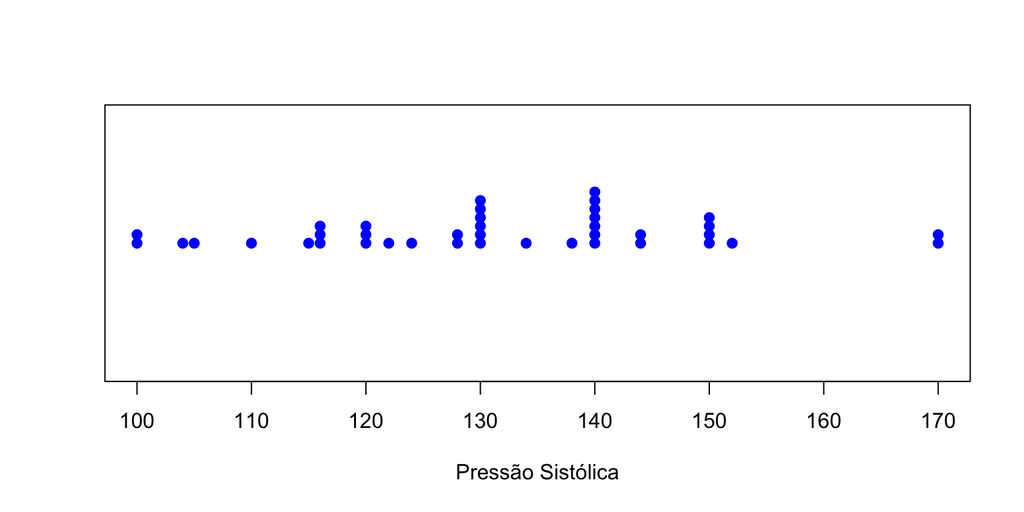

## Exemplo: Pressão sistólica

\(x_i\): pressão sistólica do paciente \(i\).

\[\bar{x}=\frac{1}{n}\sum_{i=1}^nx_i=\frac{1}{40}\sum_{i=1}^{40}x_i=131.4\]

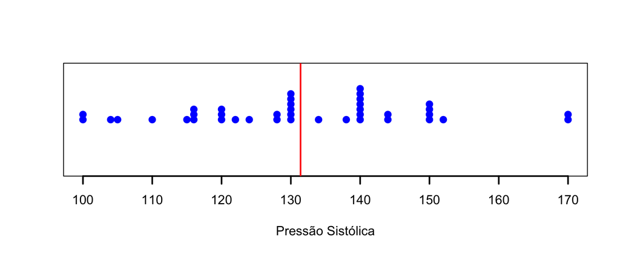

## Mediana

A mediana é o valor que deixa 50% das observações abaixo dele e 50% acima.

Determinando a mediana:

- Ordene as \(n\) observações.
- Se \(n\) é ímpar, a mediana é o valor do meio, na sequência ordenada.
- Se \(n\) é par, a mediana é a média aritmética das duas observações que caem no meio da sequência ordenada.

## Exemplo: IMC

IMC de 40 pacientes (ordem crescente):

```
##  [1] 15.204 18.957 19.040 19.044 19.435 20.426 21.228 21.790 22.229 22.503
## [11] 22.850 23.739 24.176 25.712 26.156 26.370 26.545 26.545 27.025 27.369
## [21] 27.406 27.406 27.532 27.718 28.058 28.192 28.399 28.662 28.731 28.762
## [31] 29.024 29.340 29.867 30.506 30.586 30.853 32.079 37.590 39.837 43.269
```

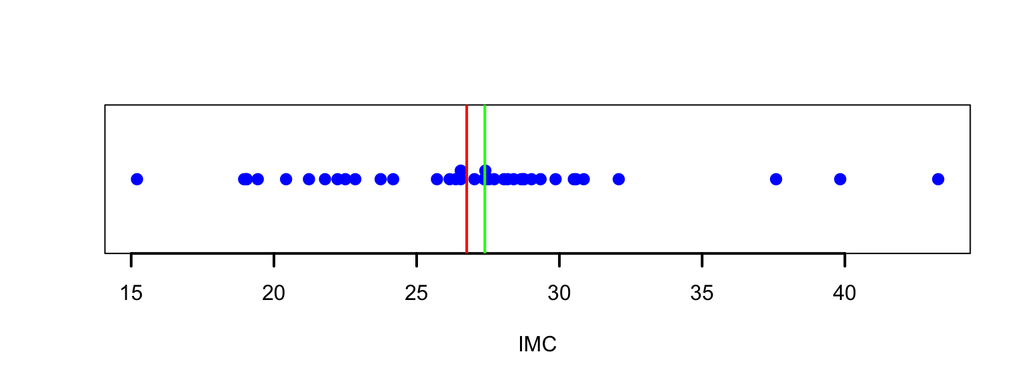

Em vermelho está a média, em verde, a mediana.

*Fonte: Biostatistics - A Guide to Design, Analysis, and Discovery. Ronald N. Forthofer, Eun Sul Lee, Mike Hernandez*

## Exemplo: IMC

A mediana é a média entre a 20ª e a 21ª observações ordenadas (\(n\) é par): \[\mbox{mediana} = \frac{27.369 + 27.406}{2} = 27.387\]

Se descartássemos o maior valor, \(43.269\), teríamos \(39\) observações e aí a mediana seria a 20ª observação ordenada: \[\mbox{mediana} = 27.369\]

## Moda

A moda é o valor mais frequente.

Tabela de frequências para a pressão sistólica dos 40 pacientes:

| Pressão Sistólica | Frequência | Pressão Sistólica | Frequência | Pressão Sistólica | Frequência |
| --- | --- | --- | --- | --- | --- |
| 100 | 2 | 120 | 3 | 138 | 1 |
| 104 | 1 | 122 | 1 | 140 | 7 |
| 105 | 1 | 124 | 1 | 144 | 2 |
| 110 | 1 | 128 | 2 | 150 | 4 |
| 115 | 1 | 130 | 6 | 152 | 1 |
| 116 | 3 | 134 | 1 | 170 | 2 |

Portanto a moda da pressão sistólica é 140.

## Exemplo: número de casamentos

| Total de vezes que casou (\(x_{i}\)) | Frequência (mulheres) | Frequência (homens) |
| --- | --- | --- |
| 0 | 5861 | 7074 |
| 1 | 2773 | 1561 |
| 2 | 105 | 43 |
| Total | 8739 | 8678 |

Qual medida de posição você usaria para apresentar a diferença entre homens e mulheres?

Fonte: http://www.census.gov/prod/2002pubs/p70-80.pdf

## Exemplo: número de casamentos

A moda entre os homens é:

\(0\).

A moda entre as mulheres é:

\(0\).

Para as mulheres, a amostra ordenada é: \[\underbrace{0\,0\,0\,\ldots0}_{\mbox{5861 0's}}\quad \underbrace{1\,1\,1\,\ldots1}_{\mbox{2773 1's}} \quad \underbrace{2\,2\,2\,\ldots2}_{\mbox{105 2's}}\]

Como \(n=8739\) é ímpar, a observaçãoo central está na posição \((1+8739)/2=4370\). A observação 4370 é 0, portanto a mediana é 0 para as mulheres. Similarmente, para os homens, a mediana é 0.

## Exemplo: número de casamentos

Média entre as mulheres:

\[\bar{x}=\frac{0\times 5861+1\times 2773+2\times 105}{8739}=0.34\]

Média entre os homens: \(\bar{x}=0.19\).

Para dados discretos com poucos valores diferentes, a mediana ignora muita informação.

## Exemplo: número de casamentos

No entanto, como neste caso temos apenas os valores 0, 1 e 2, podemos apresentar os dados usando gráficos de barra.

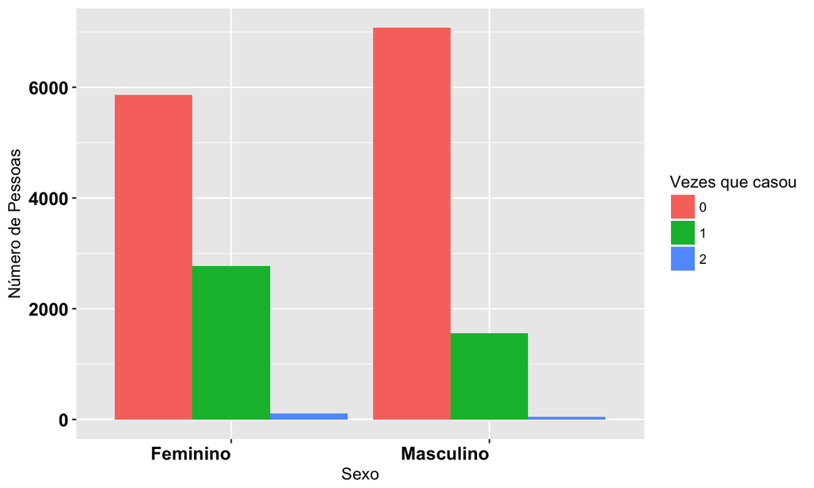

## Exemplo: número de casamentos

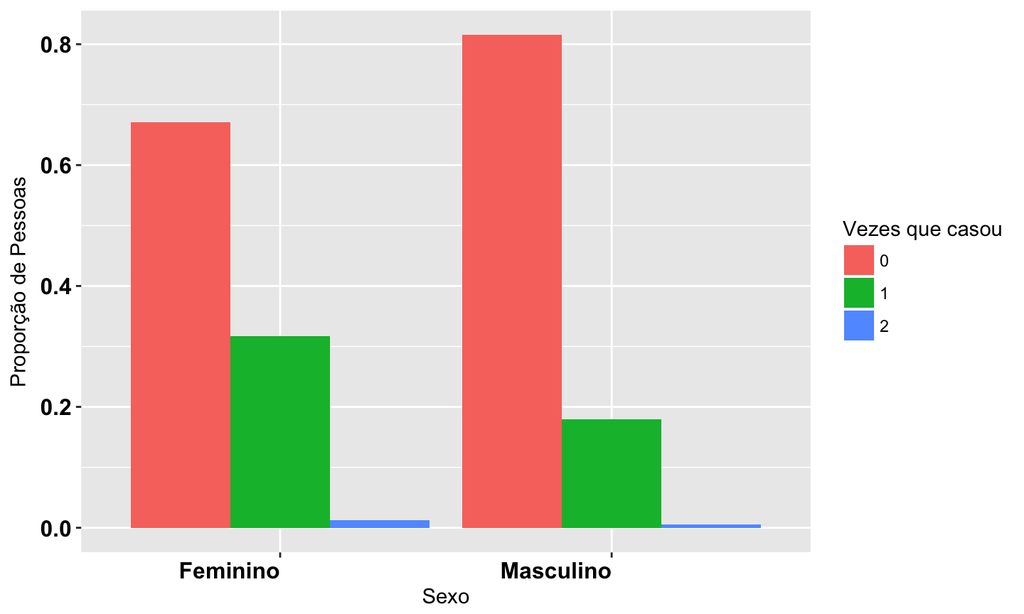

## Mediana é resistente a observações discrepantes

Considere os três conjuntos de dados abaixo:

\[A: 8,9,10,11,12\]

\[B: 8,9,10,11,100\]

\[C: 8,9,10,11,1000\]

Média de \(A\): 10. Mediana de \(A\): 10.

Média de \(B\): 27.6. Mediana de \(B\): 10.

Média de \(C\): 207.6. Mediana de \(C\): 10.

## Média, mediana e a distribuição dos dados

A figura a seguir mostra gráficos para três conjuntos de dados: A, B e C.

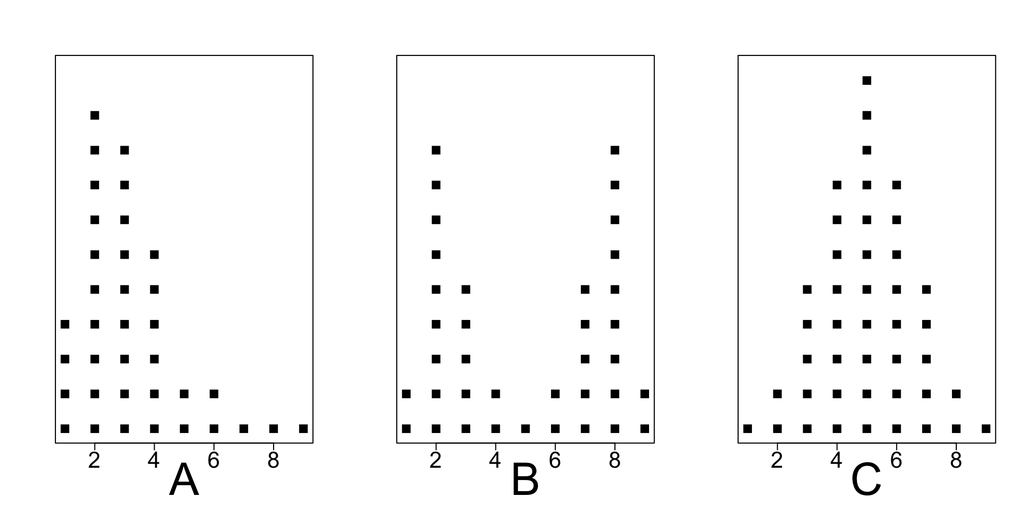

## Média, mediana e a distribuição dos dados

Para quais conjuntos de dados, você esperaria que a média e a mediana tivessem o mesmo valor?

Para quais conjuntos de dados, você esperaria que a média e a mediana tivessem valores diferentes?

Qual valor seria maior: a média ou a mediana?

Gráfico A: média é 3.36, mediana é 3.

Gráfico B: média é 5, mediana é 5.

Gráfico C: média é 5, mediana é 5.

## Assimetria (Caso Unimodal)

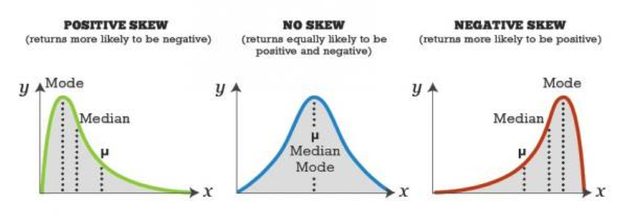

Se os dados são simétricos, a média coincide com a mediana e a moda.

Assimetria à direita (positiva): Média > Mediana > Moda

Assimetria à esquerda (negativa): Média < Mediana < Moda

## Medidas de Dispersão

## Exemplo: Idade de pacientes

Idade de pacientes em dois tratamentos: A (esquerda) e B (direita).

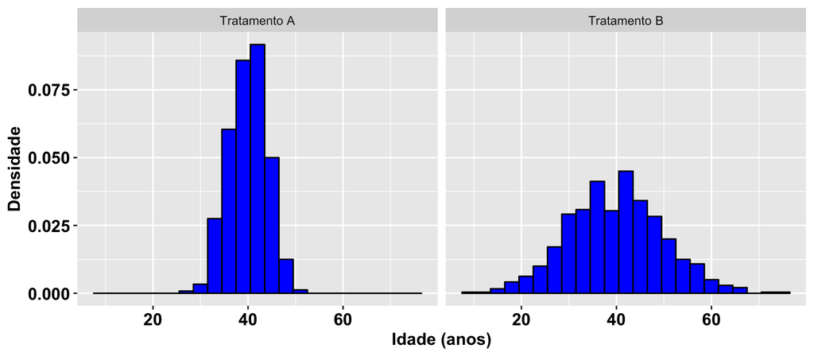

Média da idade entre pacientes do Tratamento A: 40.02. Média da idade entre pacientes do Tratamento B: 39.87.

Mediana da idade entre pacientes do Tratamento A: 40.13. Mediana da idade entre pacientes do Tratamento B: 40.05.

## Amplitude

Uma medida de dispersão é **amplitude**: a diferença entre o maior e o menor valor observado na amostra.

No Tratamento A, as idades variam de 27 a 52.

Amplitude das idades no Tratamento A: \(52-27=25\).

No Tratamento B, variam de 9 a 75.

Amplitude das idades no Tratamento B: \(75-9 = 66\).

Problema com a amplitude: utiliza apenas duas observações (a máxima e a mínima).

## Medidas de dispersão

Em ambos os tratamentos, a média e a mediana das idades é similar.

No entanto, claramente temos que as idades dos pacientes do Tratamento \(B\) são mais dispersos do que as idades dos pacientes do Tratamento \(A\).

Que medida podemos usar para considerar essa característica dos dados?

## Medidas de dispersão

Quão afastadas de uma determinada medida de posição estão as observações?

- **Desvio** de uma observação \(x_i\) da média \(\bar{x}\) é a diferença entre a observação e a média dos dados: \((x_i-\bar{x})\).
- O desvio é negativo quando a observação tem valor menor do que a média.
- O desvio é positivo quando a observação tem valor maior do que a média.
- Estamos interessados nos desvios de todos os pontos \(x_i\)’s, então poderia-se propor a seguinte medida de dispersão: \(\sum_{i=1}^n(x_i-\bar{x})\).
- Qual o problema?
- A média representa o ponto de balanço dos dados, então os desvios irão se contrabalancear, ou seja: \(\sum_{i=1}^n(x_i-\bar{x})=0\).

## Medidas de dispersão

Além do mais, uma medida de dispersão onde os desvios positivos e negativos se cancelam, não seria útil.

Queremos que se leve em conta cada desvio, independente do sinal.

Alternativas:

\(\displaystyle \sum_{i=1}^n\mid x_i-\bar{x}\mid\)

\(\displaystyle \sum_{i=1}^n(x_i-\bar{x})^2\)

Ambas alternativas evitam que desvios iguais em módulo, mas com sinais opostos, se anulem.

## Variância e Desvio-padrão

A média dos desvios ao quadrado é denominada **variância**: \[s^2=\frac{1}{n-1}\sum_{i=1}^n(x_i-\bar{x})^2\]

**Desvio padrão** é a raiz da variância:

\[s=\sqrt{\frac{1}{n-1} \sum_{i=1}^n(x_i-\bar{x})^2}\]

Interpretação: distância típica entre uma observação e a média dos dados.

Quanto maior \(s\), maior a dispersão dos dados.

## Exemplo

Conjunto de dados \(A: \{1,2,5,6,6\}\).

\(x_i\): \(\quad 1 \quad 2 \quad 5 \quad 6 \quad 6\)

\(\bar{x}\): \(\quad 4\)

\(x_i-\bar{x}\): \(\quad -3\quad -2\quad 1 \quad 2 \quad 2\)

\((x_i-\bar{x})^2\): \(\quad 9 \quad 4 \quad 1 \quad 4 \quad 4\)

\[s^2=\frac{9+4+1+4+4}{5-1}=5.5\]

## Exemplo

Conjunto de dados \(B: \{-40,0,5,20,35\}\).

\(x_i\): \(\quad -40 \quad 0 \quad 5 \quad 20 \quad 35\)

\(\bar{x}\): \(\quad 4\)

\(x_i-\bar{x}\): \(\quad -44\quad -4\quad 1 \quad 16 \quad 31\)

\((x_i-\bar{x})^2\): \(\quad 1936 \quad 16 \quad 1 \quad 256 \quad 961\)

\[s^2=\frac{1936+16+1+256+961}{5-1}=792.5\]

## Exemplo: “Qual o número ideal de filhos?”

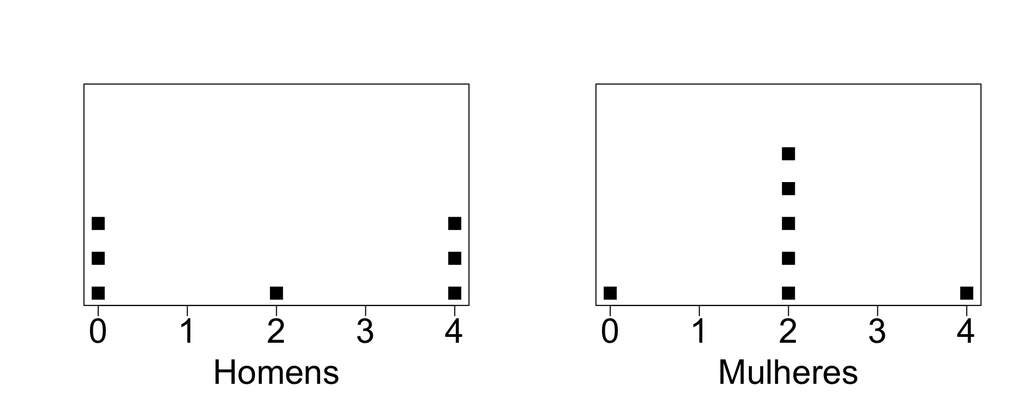

Média: 2 (para ambos os sexos).

Amplitude: 4 (para ambos os sexos).

## Exemplo: “Qual o número ideal de filhos?”

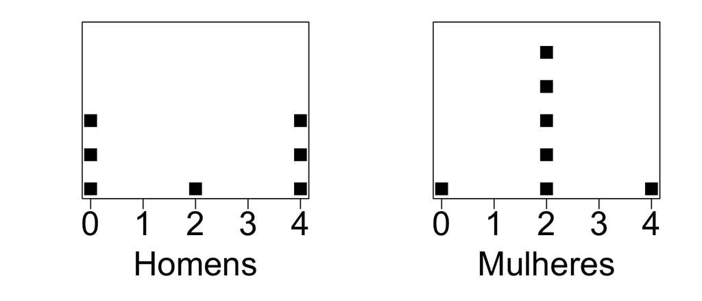

- Para homens: desvio típico da média parece estar em torno de 2.
- Para mulheres: desvio típico da média é menor do que o dos homens, pois a grande maioria das observações coincide com a própria média.
- Desvio-padrão entre homens: \(s=\sqrt{\frac{1}{n-1} \sum_{i=1}^n(x_i-\bar{x})^2}=2\).
- Desvio-padrão entre mulheres: \(s=1.15\).

## Exemplo

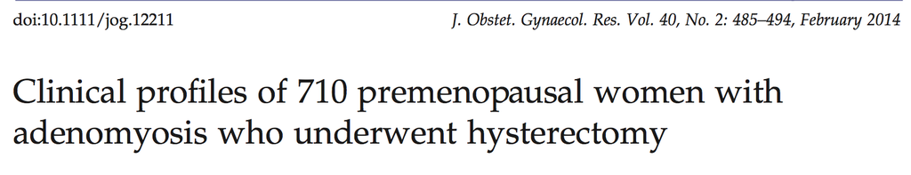

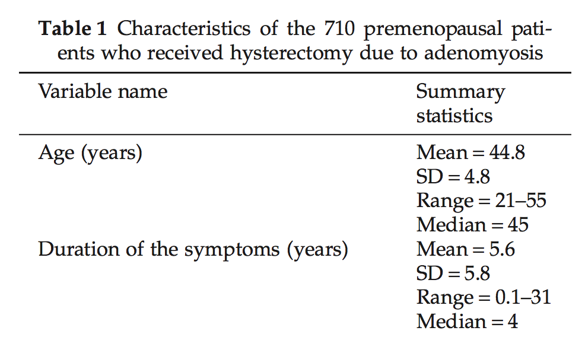

## Leitura

- [Ross](http://www.sciencedirect.com/science/book/9780123743886): seções 3.1, 3.2, 3.3, 3.4, 3.5

Slides produzidos pelos professores:

- Samara Kiihl
- Tatiana Benaglia
- Benilton Carvalho
- Rafael Maia